# Data_analysis_in_R_PhD_class_JanosSalamon

Janos Salamon

June 14, 2018

## Executive summary

The present study investigates the connection between burnout, work satisfaction and different kind of work motivation factors. Multidimensional Work Motivation Scale (MWMS; Gagné et al., 2015), Satisfaction with Work Scale (SWWS; Fouquereau & Rioux, 2002) and Shirom-Melamed Burnout Questionnaire (SMBQ; Shirom & Melamed, 2006) were used in the study. The study relies on a sample of 721 Hungarian working adults (532 female, 73.8%), who were aged between 19 and 71 (M = 37.4; SD = 11.6). These participants reported their highest level of education as primary (1.4%), secondary (34.1%) and higher (64.5%). The majority of the sample works more than 15 years ago (43.3%), 30% works between 4 and 15 years ago, while 24.7% works less than 4 years ago. There are participants (7.2%) who are self-employed, the majority works at SMEs (55.1%), and 37.7% works at large enterprises. The aim of the study was first to assess each constructs factor structure using confirmatory factor analysis (CFA), then investigate the connection between these factors, using structural equation modeling (SEM). As fit indeces did not show acceptable results for the factors of Multidimensional Work Motivation Scale (MWMS), it was necessary to continue analysis and explore factor structure by using Principal Components Analysis (PCA). PCA of MWMS suggested a 5-factor model, while there was important to drop out 2 items for a better factor structure and acceptable fit indices. Fit indices of the final model are satisfactory.

# Preparation

Loading packages

```r
library(tidyverse)
library(lavaan)
library(haven)
```

## 1. Confirmatory Factor Analysis

Confirmatory factor analysis using the lavaan package

# model for burnout

```r
burnout <- '
  Physical_B =~ burn_1 + burn_3 + burn_5 + burn_8 + burn_10 + burn_12
  Cognitive_B =~ burn_2 + burn_6 + burn_9 + burn_11 + burn_13
  Emotional_B =~ burn_4 + burn_7 + burn_14'
fit_burnout <- cfa(burnout, data = work_data, estimator = 'MLR')
summary(fit_burnout, fit.measures = TRUE, standardized = TRUE)
```

```
## lavaan (0.6-1) converged normally after  37 iterations
##
##                                                   Used       Total
##   Number of observations                           652         721
##
##   Estimator                                         ML      Robust
##   Model Fit Test Statistic                     484.424     401.710
##   Degrees of freedom                                74          74
##   P-value (Chi-square)                           0.000       0.000
##   Scaling correction factor                                  1.206
##     for the Yuan-Bentler correction (Mplus variant)
##
## Model test baseline model:
##
##   Minimum Function Test Statistic             5583.698    4418.671
##   Degrees of freedom                                91          91
##   P-value                                        0.000       0.000
##
## User model versus baseline model:
##
##   Comparative Fit Index (CFI)                    0.925       0.924
##   Tucker-Lewis Index (TLI)                       0.908       0.907
##
##   Robust Comparative Fit Index (CFI)                            NA
##   Robust Tucker-Lewis Index (TLI)                               NA
##
## Loglikelihood and Information Criteria:
##
##   Loglikelihood user model (H0)             -13363.392  -13363.392
##   Loglikelihood unrestricted model (H1)     -13121.180  -13121.180
##
##   Number of free parameters                         31          31
##   Akaike (AIC)                               26788.783   26788.783
##   Bayesian (BIC)                             26927.665   26927.665
##   Sample-size adjusted Bayesian (BIC)        26829.240   26829.240
##
## Root Mean Square Error of Approximation:
##
##   RMSEA                                          0.092       0.082
##   90 Percent Confidence Interval          0.085  0.100       0.075  0.090
```

[output cut: 47 more lines]

```
##    .burn_5            0.852    0.069   12.337    0.000    0.852    0.384
##    .burn_8            0.881    0.066   13.312    0.000    0.881    0.342
##    .burn_10           0.541    0.046   11.678    0.000    0.541    0.216
##    .burn_12           1.155    0.084   13.776    0.000    1.155    0.442
##    .burn_2            0.902    0.057   15.943    0.000    0.902    0.592
##    .burn_6            0.584    0.045   12.838    0.000    0.584    0.384
##    .burn_9            0.569    0.045   12.660    0.000    0.569    0.357
##    .burn_11           0.475    0.046   10.397    0.000    0.475    0.273
##    .burn_13           0.741    0.056   13.339    0.000    0.741    0.430
##    .burn_4            0.802    0.070   11.504    0.000    0.802    0.487
##    .burn_7            0.753    0.087    8.628    0.000    0.753    0.398
##    .burn_14           0.711    0.082    8.677    0.000    0.711    0.435
##     Physical_B        0.833    0.086    9.719    0.000    1.000    1.000
##     Cognitive_B       0.623    0.078    7.994    0.000    1.000    1.000
##     Emotional_B       0.846    0.103    8.203    0.000    1.000    1.000
```

Fit indices highlighted that the hypothesized representation of the constructs is satisfactory (CFI = .924, TLI = .907, RMSEA = .082 [90% CI = .075-.090]).

# model for work motivation

```r
work_motiv <- '
  Amotiv =~ mwms_4 + mwms_10 + mwms_16
  Ext_Mat =~ mwms_6 + mwms_12 + mwms_18
  Ext_Soc =~ mwms_1 + mwms_7 + mwms_13
  Introj =~ mwms_2 + mwms_8 + mwms_14 + mwms_19
  Ident =~ mwms_5 + mwms_11 + mwms_17
  Intrin =~ mwms_3 + mwms_9 + mwms_15'
fit_work_motiv <- cfa(work_motiv, data = work_data, estimator = 'MLR')
summary(fit_work_motiv, fit.measures = TRUE, standardized = TRUE)
```

```
## lavaan (0.6-1) converged normally after  58 iterations
##
##   Number of observations                           721
##
##   Estimator                                         ML      Robust
##   Model Fit Test Statistic                     716.443     604.750
##   Degrees of freedom                               137         137
##   P-value (Chi-square)                           0.000       0.000
##   Scaling correction factor                                  1.185
##     for the Yuan-Bentler correction (Mplus variant)
##
## Model test baseline model:
##
##   Minimum Function Test Statistic             6797.326    5182.600
##   Degrees of freedom                               171         171
##   P-value                                        0.000       0.000
##
## User model versus baseline model:
##
##   Comparative Fit Index (CFI)                    0.913       0.907
##   Tucker-Lewis Index (TLI)                       0.891       0.884
##
##   Robust Comparative Fit Index (CFI)                            NA
##   Robust Tucker-Lewis Index (TLI)                               NA
##
## Loglikelihood and Information Criteria:
##
##   Loglikelihood user model (H0)             -22463.862  -22463.862
##   Loglikelihood unrestricted model (H1)     -22105.640  -22105.640
##
##   Number of free parameters                         53          53
##   Akaike (AIC)                               45033.723   45033.723
##   Bayesian (BIC)                             45276.497   45276.497
##   Sample-size adjusted Bayesian (BIC)        45108.207   45108.207
##
## Root Mean Square Error of Approximation:
##
##   RMSEA                                          0.077       0.069
##   90 Percent Confidence Interval          0.071  0.082       0.064  0.074
##   P-value RMSEA <= 0.05                          0.000       0.000
```

[output cut: 77 more lines]

```
##    .mwms_8            1.212    0.109   11.105    0.000    1.212    0.593
##    .mwms_14           2.219    0.145   15.305    0.000    2.219    0.657
##    .mwms_19           1.487    0.126   11.819    0.000    1.487    0.620
##    .mwms_5            0.738    0.074    9.973    0.000    0.738    0.466
##    .mwms_11           0.790    0.091    8.674    0.000    0.790    0.478
##    .mwms_17           0.619    0.086    7.181    0.000    0.619    0.345
##    .mwms_3            0.827    0.090    9.204    0.000    0.827    0.362
##    .mwms_9            0.385    0.051    7.584    0.000    0.385    0.141
##    .mwms_15           0.249    0.043    5.864    0.000    0.249    0.095
##     Amotiv            1.124    0.139    8.060    0.000    1.000    1.000
##     Ext_Mat           1.283    0.164    7.803    0.000    1.000    1.000
##     Ext_Soc           1.147    0.150    7.622    0.000    1.000    1.000
##     Introj            1.002    0.150    6.674    0.000    1.000    1.000
##     Ident             0.846    0.101    8.384    0.000    1.000    1.000
##     Intrin            1.459    0.146    9.964    0.000    1.000    1.000
```

Fit indices show that the hypothesized representation of the constructs is unsatisfactory (CFI = .907, TLI = .884, RMSEA = .069 [90% CI = .064-.074]).

# model for satisfaction

```r
work_satisf <- ' work_satisf =~ swws_1 + swws_2 + swws_3 + swws_4 + swws_5
  swws_2 ~~ swws_5'
fit_work_satisf <- cfa(work_satisf, data = work_data, estimator = 'MLR')
summary(fit_work_satisf, fit.measures = TRUE, standardized = TRUE, modindices = TRUE)
```

```
## lavaan (0.6-1) converged normally after  23 iterations
##
##                                                   Used       Total
##   Number of observations                           656         721
##
##   Estimator                                         ML      Robust
##   Model Fit Test Statistic                       8.394       6.161
##   Degrees of freedom                                 4           4
##   P-value (Chi-square)                           0.078       0.187
##   Scaling correction factor                                  1.362
##     for the Yuan-Bentler correction (Mplus variant)
##
## Model test baseline model:
##
##   Minimum Function Test Statistic             1770.477    1232.191
##   Degrees of freedom                                10          10
##   P-value                                        0.000       0.000
##
## User model versus baseline model:
##
##   Comparative Fit Index (CFI)                    0.998       0.998
##   Tucker-Lewis Index (TLI)                       0.994       0.996
##
##   Robust Comparative Fit Index (CFI)                            NA
##   Robust Tucker-Lewis Index (TLI)                               NA
##
## Loglikelihood and Information Criteria:
##
##   Loglikelihood user model (H0)              -5372.497   -5372.497
##   Loglikelihood unrestricted model (H1)      -5368.300   -5368.300
##
##   Number of free parameters                         11          11
##   Akaike (AIC)                               10766.994   10766.994
##   Bayesian (BIC)                             10816.342   10816.342
##   Sample-size adjusted Bayesian (BIC)        10781.417   10781.417
##
## Root Mean Square Error of Approximation:
##
##   RMSEA                                          0.041       0.029
##   90 Percent Confidence Interval          0.000  0.080       0.000  0.065
```

[output cut: 35 more lines]

```
##    .swws_5            1.391    0.118   11.787    0.000    1.391    0.389
##     work_satisf       2.092    0.132   15.823    0.000    1.000    1.000
##
## Modification Indices:
##
##       lhs op    rhs    mi    epc sepc.lv sepc.all sepc.nox
## 13 swws_1 ~~ swws_2 0.086  0.018   0.018    0.021    0.021
## 14 swws_1 ~~ swws_3 0.241  0.030   0.030    0.055    0.055
## 15 swws_1 ~~ swws_4 6.195 -0.125  -0.125   -0.139   -0.139
## 16 swws_1 ~~ swws_5 3.322  0.132   0.132    0.154    0.154
## 17 swws_2 ~~ swws_3 0.094 -0.016  -0.016   -0.019   -0.019
## 18 swws_2 ~~ swws_4 0.000  0.001   0.001    0.001    0.001
## 19 swws_3 ~~ swws_4 4.470  0.096   0.096    0.106    0.106
## 20 swws_3 ~~ swws_5 5.334 -0.144  -0.144   -0.166   -0.166
## 21 swws_4 ~~ swws_5 0.393  0.043   0.043    0.029    0.029
```

Fit indices show that the hypothesized representation of the constructs is good (CFI = .998, TLI = .996, RMSEA = .029 [90% CI = .000-.065]), taking into account the simlicity of the model, and the range of the confidence inteval.

Modification Indices suggested error covariances between the following items: swws_2 and swws_5, thus these are corrected in the final model.

## SEM model

```r
my_model <- '
  # measurement model
    burnout =~ Physical_B + Emotional_B + Cognitive_B
                  Physical_B =~ burn_1 + burn_2 + burn_3 + burn_4 + burn_5 + burn_6
                  Emotional_B =~ burn_7 + burn_8 + burn_9 + burn_10 + burn_11
                  Cognitive_B =~ burn_12 + burn_13 + burn_14

    Amotiv =~ mwms_4 + mwms_10 + mwms_16
    Ext_Mat =~ mwms_6 + mwms_12 + mwms_18
    Ext_Soc =~ mwms_1 + mwms_7 + mwms_13
    Introj =~ mwms_2 + mwms_8 + mwms_14 + mwms_19
    Ident =~ mwms_5 + mwms_11 + mwms_17
    Intrin =~ mwms_3 + mwms_9 + mwms_15

    work_satisf =~ swws_1 + swws_2 + swws_3 + swws_4 + swws_5

# regressions
    burnout ~ Amotiv + Ext_Mat + Ext_Soc + Introj + Ident + Intrin
    work_satisf ~ Amotiv + Ext_Mat + Ext_Soc + Introj + Ident + Intrin
    burnout ~~ work_satisf'
```

# model fit and summary of model fit

```r
my_model_fit <- cfa(my_model, data = work_data, estimator = 'MLR')
```

```
## Warning in lav_object_post_check(object): lavaan WARNING: some estimated lv
## variances are negative
```

Output shows warning message: “some estimated lv variances are negative”, which was expected based on previous results.

```r
summary(my_model_fit, fit.measures=TRUE, standardized = TRUE)
```

```
## lavaan (0.6-1) converged normally after  84 iterations
##
##                                                   Used       Total
##   Number of observations                           622         721
##
##   Estimator                                         ML      Robust
##   Model Fit Test Statistic                    2578.985    2305.488
##   Degrees of freedom                               634         634
##   P-value (Chi-square)                           0.000       0.000
##   Scaling correction factor                                  1.119
##     for the Yuan-Bentler correction (Mplus variant)
##
## Model test baseline model:
##
##   Minimum Function Test Statistic            14590.076   12498.017
##   Degrees of freedom                               703         703
##   P-value                                        0.000       0.000
##
## User model versus baseline model:
##
##   Comparative Fit Index (CFI)                    0.860       0.858
##   Tucker-Lewis Index (TLI)                       0.845       0.843
##
##   Robust Comparative Fit Index (CFI)                            NA
##   Robust Tucker-Lewis Index (TLI)                               NA
##
## Loglikelihood and Information Criteria:
##
##   Loglikelihood user model (H0)             -37053.258  -37053.258
##   Loglikelihood unrestricted model (H1)     -35763.765  -35763.765
##
##   Number of free parameters                        107         107
##   Akaike (AIC)                               74320.515   74320.515
##   Bayesian (BIC)                             74794.840   74794.840
##   Sample-size adjusted Bayesian (BIC)        74455.131   74455.131
##
## Root Mean Square Error of Approximation:
##
##   RMSEA                                          0.070       0.065
##   90 Percent Confidence Interval          0.067  0.073       0.062  0.068
```

[output cut: 148 more lines]

```
##    .swws_2            1.536    0.108   14.198    0.000    1.536    0.604
##    .swws_3            0.445    0.051    8.700    0.000    0.445    0.209
##    .swws_4            1.539    0.111   13.855    0.000    1.539    0.579
##    .swws_5            1.436    0.111   12.893    0.000    1.436    0.400
##    .burnout           0.462    0.058    8.005    0.000    0.681    0.681
##     Physical_B        0.203    0.037    5.509    0.000    0.230    0.230
##     Emotional_B      -0.049    0.015   -3.193    0.001   -0.075   -0.075
##     Cognitive_B       0.089    0.058    1.528    0.126    0.056    0.056
##     Amotiv            1.133    0.153    7.421    0.000    1.000    1.000
##     Ext_Mat           1.232    0.172    7.150    0.000    1.000    1.000
##     Ext_Soc           1.190    0.160    7.413    0.000    1.000    1.000
##     Introj            0.974    0.160    6.102    0.000    1.000    1.000
##     Ident             0.854    0.105    8.105    0.000    1.000    1.000
##     Intrin            1.381    0.154    8.945    0.000    1.000    1.000
##    .work_satisf       0.827    0.083    9.951    0.000    0.400    0.400
```

Fit indices highlighted that the hypothesized representation of the constructs is unsatisfactory (CFI = .858, TLI = .843, RMSEA = .065 [90% CI = .062-.068]). These results were expected based on the fit indices of some elements of the model (showed in previous results).

# Plotting the models with semPlot

```r
library(semPlot)
```

# Seeing the clean model structure

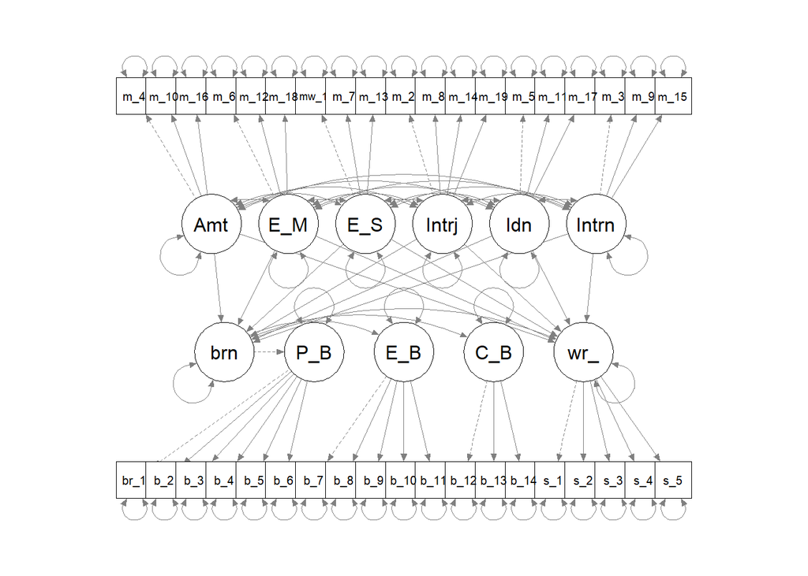

```r
semPaths(my_model_fit)
```

# Getting standardized estimates

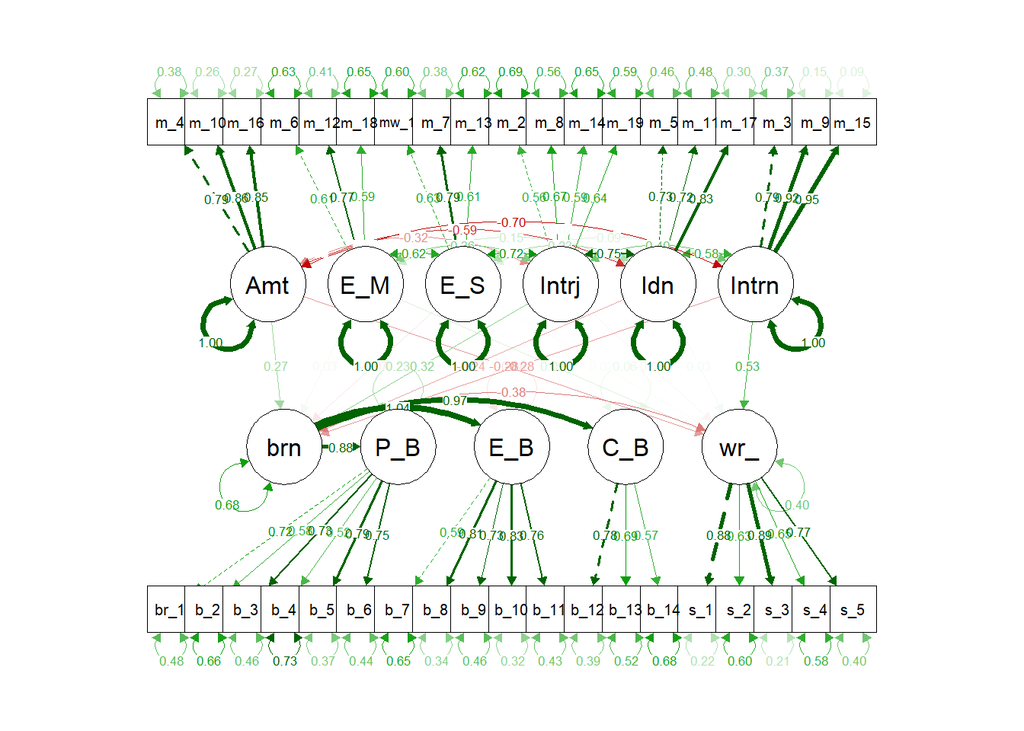

```r
semPaths(my_model_fit, "std")
```

The model shows the previously indicated negative correlations between some variables. Based on the unsatisfactory fit indices of previously hypothesized representation of the constructs it is suggested to continue the analysis with exploratory factor analysis.

## 2. Dimension reduction (Principal Components Analysis)

PCA for exploring the factor sturcture of motivation, using the Multidimensional Work Motivation Scale, because fit indices in CFA were unsatisfactory in the original factor structure.

# Loading packages

```r
library(corpcor)
library(GPArotation)
library(psych)
library(devtools)
library(DSUR.noof)
```

```r
motiv <-
  work_data %>%
  as_tibble() %>%
  select(mwms_1:mwms_19)
```

# Preliminary analysis for EFA

```r
cortest.bartlett(motiv, n = 721)
```

```
## R was not square, finding R from data
```

```
## $chisq
## [1] 6720.334
##
## $p.value
## [1] 0
##
## $df
## [1] 171
```

Bartlett’s test is significant, x2(171) = 6,720, p < .001), so factor analysis is appropriate.

```r
kmo(motiv)
```

```
## $overall
## [1] 0.8607139
##
## $report
## [1] "The KMO test yields a degree of common variance meritorious."
##
## $individual
##    mwms_1    mwms_2    mwms_3    mwms_4    mwms_5    mwms_6    mwms_7
## 0.8284813 0.8422798 0.9442647 0.8735538 0.9295276 0.6980449 0.8371907
##    mwms_8    mwms_9   mwms_10   mwms_11   mwms_12   mwms_13   mwms_14
## 0.8713680 0.8248757 0.8735576 0.8955848 0.7800927 0.8122528 0.8192085
##   mwms_15   mwms_16   mwms_17   mwms_18   mwms_19
## 0.8262261 0.9159571 0.8756431 0.7793771 0.8870321
##
## $AIS
```

[output cut: 162 more lines]

KMO statistics show that overall KMO is 0.86, which means: “The KMO test yields a degree of common variance meritorious.” KMO values for Individual variables also acceptable (all are > .5).

```r
det(cor(motiv))
```

```
## [1] 8.046915e-05
```

Determinant of the correlation matrix (8.046915e-05) is greater than 0.00001, thus determinant does not seem problematic either.

# Finding the optimal number of factors

```r
pc1 <- principal(motiv, nfactors = 19, rotate = "none")
pc1
```

```
## Principal Components Analysis
## Call: principal(r = motiv, nfactors = 19, rotate = "none")
## Standardized loadings (pattern matrix) based upon correlation matrix
##           PC1   PC2   PC3   PC4   PC5   PC6   PC7   PC8   PC9  PC10  PC11
## mwms_1   0.35  0.53  0.03 -0.45 -0.17 -0.17  0.29  0.18  0.07  0.27  0.27
## mwms_2   0.37  0.51  0.17 -0.40  0.13 -0.16 -0.23  0.41  0.03 -0.03 -0.34
## mwms_3   0.74 -0.23 -0.18 -0.17  0.21  0.27  0.08  0.09  0.05  0.00 -0.06
## mwms_4  -0.65  0.31  0.21  0.00  0.45  0.21  0.06 -0.05 -0.04  0.06  0.06
## mwms_5   0.71  0.00  0.19  0.13  0.15 -0.16  0.05 -0.19 -0.24  0.33 -0.15
## mwms_6   0.03  0.52 -0.51  0.23  0.32 -0.21 -0.15 -0.22  0.33  0.17 -0.15
## mwms_7   0.33  0.69 -0.05 -0.27 -0.08 -0.04  0.10 -0.32  0.07  0.05  0.12
## mwms_8   0.53  0.37  0.19 -0.22  0.18 -0.17 -0.41 -0.22 -0.19 -0.31  0.23
## mwms_9   0.77 -0.26 -0.20 -0.19  0.24  0.31  0.04 -0.03  0.00 -0.04  0.09
## mwms_10 -0.70  0.36  0.18 -0.02  0.34  0.19  0.13  0.06 -0.02  0.01  0.09
## mwms_11  0.65  0.00  0.26  0.30  0.13 -0.25  0.35 -0.01 -0.01 -0.14  0.04
## mwms_12  0.19  0.57 -0.48  0.22  0.02 -0.14  0.25  0.16  0.02 -0.37  0.01
## mwms_13  0.01  0.73 -0.04 -0.05 -0.20  0.33  0.14 -0.16 -0.27  0.00 -0.30
## mwms_14  0.38  0.47  0.39  0.19 -0.31  0.33  0.00 -0.09  0.20 -0.15 -0.07
## mwms_15  0.79 -0.28 -0.23 -0.10  0.18  0.33  0.04  0.01  0.05 -0.01  0.02
## mwms_16 -0.72  0.30  0.25 -0.02  0.28  0.06  0.08  0.06  0.09 -0.06  0.01
## mwms_17  0.70 -0.01  0.31  0.31  0.21 -0.12  0.09  0.11 -0.14  0.01 -0.03
## mwms_18  0.06  0.58 -0.35  0.41 -0.07  0.18 -0.23  0.26 -0.29  0.17  0.22
## mwms_19  0.59  0.22  0.37  0.32 -0.07  0.16 -0.19  0.11  0.32  0.12  0.12
##          PC12  PC13  PC14  PC15  PC16  PC17  PC18  PC19 h2       u2 com
## mwms_1   0.12  0.07 -0.05 -0.16  0.13 -0.01 -0.02  0.01  1  3.3e-16 6.4
## mwms_2  -0.07  0.06 -0.03  0.05 -0.13  0.05  0.01 -0.01  1  3.1e-15 6.3
## mwms_3   0.14  0.00  0.16  0.12  0.04 -0.37  0.02 -0.01  1  1.0e-15 3.0
## mwms_4  -0.07  0.03 -0.23 -0.19 -0.13 -0.13  0.22 -0.01  1 -6.7e-16 4.2
## mwms_5   0.34 -0.16  0.00  0.06 -0.10  0.09  0.06  0.00  1 -6.7e-16 3.5
## mwms_6   0.01  0.15 -0.01 -0.08  0.10 -0.01 -0.08  0.00  1 -6.7e-16 5.9
## mwms_7  -0.27 -0.11 -0.02  0.32 -0.12 -0.02  0.05  0.00  1  2.1e-15 3.8
## mwms_8   0.10  0.02  0.06 -0.11  0.07 -0.04 -0.03  0.03  1  5.6e-16 6.8
## mwms_9  -0.04  0.05 -0.01 -0.04  0.01  0.21 -0.01 -0.22  1  5.6e-16 2.7
## mwms_10  0.07 -0.09  0.05  0.06 -0.11  0.02 -0.36  0.02  1  8.9e-16 3.4
## mwms_11 -0.11  0.33  0.21 -0.05 -0.16  0.01  0.01  0.01  1  3.3e-16 4.4
## mwms_12  0.15 -0.28 -0.07 -0.04 -0.05  0.02  0.06 -0.01  1  1.1e-16 5.3
## mwms_13 -0.13 -0.02  0.17 -0.20  0.11  0.00 -0.02  0.01  1 -2.2e-16 3.2
## mwms_14  0.25  0.20 -0.23  0.09  0.00  0.00 -0.03 -0.02  1  5.6e-16 8.0
## mwms_15 -0.05  0.02 -0.08 -0.03 -0.01  0.17  0.01  0.23  1  1.4e-15 2.4
## mwms_16  0.12  0.02  0.21  0.19  0.25  0.15  0.19  0.02  1  1.1e-16 3.3
```

[output cut: 9 more lines]

```
## Cumulative Proportion 0.31 0.48 0.56 0.62 0.67 0.72 0.75 0.79 0.81 0.84
##                       PC11 PC12 PC13 PC14 PC15 PC16 PC17 PC18 PC19
## SS loadings           0.48 0.45 0.42 0.36 0.35 0.30 0.26 0.24 0.10
## Proportion Var        0.03 0.02 0.02 0.02 0.02 0.02 0.01 0.01 0.01
## Cumulative Var        0.87 0.89 0.91 0.93 0.95 0.97 0.98 0.99 1.00
## Proportion Explained  0.03 0.02 0.02 0.02 0.02 0.02 0.01 0.01 0.01
## Cumulative Proportion 0.87 0.89 0.91 0.93 0.95 0.97 0.98 0.99 1.00
##
## Mean item complexity =  4.6
## Test of the hypothesis that 19 components are sufficient.
##
## The root mean square of the residuals (RMSR) is  0
##  with the empirical chi square  0  with prob <  NA
##
## Fit based upon off diagonal values = 1
```

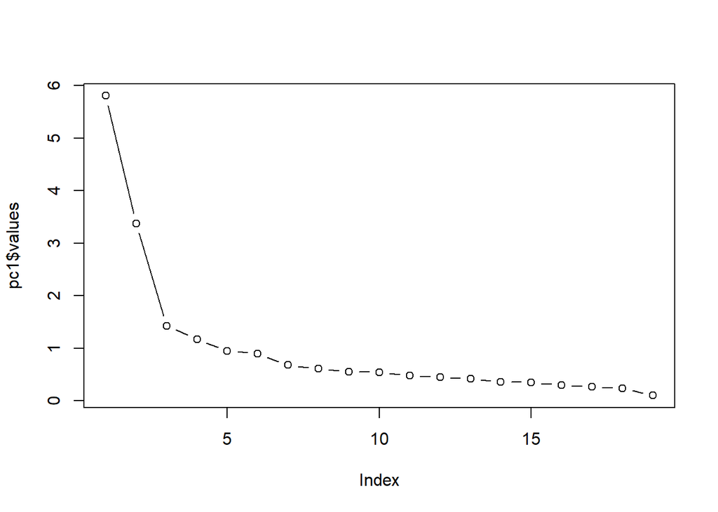

```r
plot(pc1$values, type = "b")
```

```r
pc2 <- principal(motiv, nfactors = 6, rotate = "promax")
pc2
```

```
## Principal Components Analysis
## Call: principal(r = motiv, nfactors = 6, rotate = "promax")
## Standardized loadings (pattern matrix) based upon correlation matrix
##           RC1   RC6   RC4   RC5   RC3   RC2   h2    u2 com
## mwms_1  -0.10 -0.17  0.84 -0.22 -0.06  0.06 0.67 0.334 1.3
## mwms_2   0.03  0.11  0.78  0.15 -0.05 -0.03 0.63 0.373 1.1
## mwms_3   0.86  0.01  0.03 -0.01 -0.01 -0.03 0.78 0.218 1.0
## mwms_4   0.06  0.01 -0.06  0.93  0.02  0.01 0.81 0.192 1.0
## mwms_5   0.09  0.65  0.10 -0.08  0.04 -0.01 0.61 0.393 1.1
## mwms_6   0.01  0.13  0.04  0.14  0.90 -0.30 0.72 0.275 1.3
## mwms_7   0.00 -0.10  0.66 -0.04  0.17  0.19 0.66 0.340 1.4
## mwms_8   0.08  0.34  0.58  0.11  0.00 -0.04 0.57 0.434 1.7
## mwms_9   0.95 -0.01  0.02  0.01 -0.03 -0.04 0.89 0.107 1.0
## mwms_10 -0.03 -0.08 -0.02  0.83  0.03  0.05 0.81 0.194 1.0
## mwms_11 -0.13  0.84 -0.01 -0.09  0.10  0.01 0.66 0.335 1.1
## mwms_12 -0.06  0.03  0.10 -0.15  0.78 -0.03 0.66 0.344 1.1
## mwms_13  0.07 -0.30  0.27  0.12  0.16  0.58 0.69 0.310 2.3
## mwms_14 -0.06  0.25  0.06 -0.01 -0.17  0.84 0.76 0.244 1.3
## mwms_15  0.92 -0.01 -0.08 -0.07  0.01  0.02 0.90 0.098 1.0
## mwms_16 -0.21 -0.03  0.02  0.72 -0.04 -0.01 0.76 0.242 1.2
## mwms_17  0.04  0.87 -0.07  0.04  0.05  0.08 0.74 0.260 1.0
## mwms_18  0.02  0.00 -0.22  0.00  0.68  0.35 0.67 0.335 1.7
## mwms_19  0.02  0.60 -0.08  0.02 -0.07  0.55 0.66 0.335 2.0
##
##                        RC1  RC6  RC4  RC5  RC3  RC2
## SS loadings           2.68 2.65 2.32 2.37 1.95 1.67
## Proportion Var        0.14 0.14 0.12 0.12 0.10 0.09
## Cumulative Var        0.14 0.28 0.40 0.53 0.63 0.72
## Proportion Explained  0.20 0.19 0.17 0.17 0.14 0.12
## Cumulative Proportion 0.20 0.39 0.56 0.73 0.88 1.00
##
##  With component correlations of
##       RC1   RC6   RC4   RC5   RC3  RC2
## RC1  1.00  0.55  0.23 -0.58 -0.03 0.03
## RC6  0.55  1.00  0.28 -0.47 -0.07 0.10
## RC4  0.23  0.28  1.00 -0.08  0.33 0.36
## RC5 -0.58 -0.47 -0.08  1.00  0.08 0.01
## RC3 -0.03 -0.07  0.33  0.08  1.00 0.38
## RC2  0.03  0.10  0.36  0.01  0.38 1.00
##
## Mean item complexity =  1.3
## Test of the hypothesis that 6 components are sufficient.
##
## The root mean square of the residuals (RMSR) is  0.05
##  with the empirical chi square  627.28  with prob <  1.6e-89
##
## Fit based upon off diagonal values = 0.97
```

```r
print.psych(pc2, cut = 0.3, sort = TRUE)
```

```
## Principal Components Analysis
## Call: principal(r = motiv, nfactors = 6, rotate = "promax")
## Standardized loadings (pattern matrix) based upon correlation matrix
##         item   RC1   RC6   RC4   RC5   RC3   RC2   h2    u2 com
## mwms_9     9  0.95                               0.89 0.107 1.0
## mwms_15   15  0.92                               0.90 0.098 1.0
## mwms_3     3  0.86                               0.78 0.218 1.0
## mwms_17   17        0.87                         0.74 0.260 1.0
## mwms_11   11        0.84                         0.66 0.335 1.1
## mwms_5     5        0.65                         0.61 0.393 1.1
## mwms_19   19        0.60                    0.55 0.66 0.335 2.0
## mwms_1     1              0.84                   0.67 0.334 1.3
## mwms_2     2              0.78                   0.63 0.373 1.1
## mwms_7     7              0.66                   0.66 0.340 1.4
## mwms_8     8        0.34  0.58                   0.57 0.434 1.7
## mwms_4     4                    0.93             0.81 0.192 1.0
## mwms_10   10                    0.83             0.81 0.194 1.0
## mwms_16   16                    0.72             0.76 0.242 1.2
## mwms_6     6                          0.90 -0.30 0.72 0.275 1.3
## mwms_12   12                          0.78       0.66 0.344 1.1
## mwms_18   18                          0.68  0.35 0.67 0.335 1.7
## mwms_14   14                                0.84 0.76 0.244 1.3
## mwms_13   13       -0.30                    0.58 0.69 0.310 2.3
##
##                        RC1  RC6  RC4  RC5  RC3  RC2
## SS loadings           2.68 2.65 2.32 2.37 1.95 1.67
## Proportion Var        0.14 0.14 0.12 0.12 0.10 0.09
## Cumulative Var        0.14 0.28 0.40 0.53 0.63 0.72
## Proportion Explained  0.20 0.19 0.17 0.17 0.14 0.12
## Cumulative Proportion 0.20 0.39 0.56 0.73 0.88 1.00
##
##  With component correlations of
##       RC1   RC6   RC4   RC5   RC3  RC2
## RC1  1.00  0.55  0.23 -0.58 -0.03 0.03
## RC6  0.55  1.00  0.28 -0.47 -0.07 0.10
## RC4  0.23  0.28  1.00 -0.08  0.33 0.36
## RC5 -0.58 -0.47 -0.08  1.00  0.08 0.01
## RC3 -0.03 -0.07  0.33  0.08  1.00 0.38
## RC2  0.03  0.10  0.36  0.01  0.38 1.00
##
## Mean item complexity =  1.3
## Test of the hypothesis that 6 components are sufficient.
##
## The root mean square of the residuals (RMSR) is  0.05
##  with the empirical chi square  627.28  with prob <  1.6e-89
##
## Fit based upon off diagonal values = 0.97
```

6-factor model’s fit shows upon off diagonal values = 0.97, which means a good fit. Factor structure does not clear, constructs are also mixed in a not meaningful way.